# Project 4

## Training Model

### Splitting the Data

We will be performing a simple machine learning procedure, so the next step will be to randomly split the dataset into an 70% / 30% ratio for training and testing, respectively

```r
print(cor(df_num[, c(1:23)]))
```

```
##                                 class   cap_shape   cap_surface    cap_color
## class                     1.000000000 -0.07442866 -0.0468588384 -0.094145965
## cap_shape                -0.074428656  1.00000000 -0.1360355590  0.055995891
## cap_surface              -0.046858838 -0.13603556  1.0000000000 -0.052383041
## cap_color                -0.094145965  0.05599589 -0.0523830408  1.000000000
## bruises                  -0.435561947  0.17500456 -0.2285895204  0.035063040
## odor                      0.112626833  0.39178575 -0.1865878728  0.063718249
## gill_attachment           0.071944939 -0.04736870 -0.0581044722 -0.056427238
## gill_spacing              0.264159844  0.07020886 -0.2044475297 -0.144347669
## gill_size                -0.215288952  0.07158188 -0.0423561776 -0.122150503
## gill_color               -0.235281902  0.04460456 -0.0752318996  0.012597579
## stalk_shape               0.592445682  0.19355638 -0.1735538666  0.045344886
## stalk_root                0.271684328  0.03249354  0.0546906075 -0.361274640
## stalk_surface_above_ring  0.246214816 -0.12052939  0.0918231084  0.013669579
## stalk_surface_below_ring  0.189169644 -0.13493275  0.0082750463  0.064299207
## stalk_color_above_ring    0.052756291  0.12337621 -0.0245223940  0.176569415
## stalk_color_below_ring    0.045345317  0.11485028 -0.0234544798  0.168681357
## veil_type                          NA          NA            NA           NA
## veil_color               -0.047920723 -0.01726316  0.0387019345 -0.006054078
## ring_number              -0.008615448 -0.11327544  0.0442890890 -0.014443061
## ring_type                 0.098533305 -0.15075739  0.1973860432  0.061151616
## spore_print_color        -0.437212476  0.04884640 -0.0122651174  0.078088269
## population               -0.203882302  0.16741067 -0.0003903856  0.203156911
## habitat                   0.102083009  0.15257501 -0.0754217326  0.226197897
##                              bruises         odor gill_attachment gill_spacing
## class                    -0.43556195  0.112626833     0.071944939   0.26415984
## cap_shape                 0.17500456  0.391785745    -0.047368698   0.07020886
## cap_surface              -0.22858952 -0.186587873    -0.058104472  -0.20444753
## cap_color                 0.03506304  0.063718249    -0.056427238  -0.14434767
## bruises                   1.00000000  0.025353056    -0.064351010   0.43918287
## odor                      0.02535306  1.000000000    -0.012427493   0.12926755
## gill_attachment          -0.06435101 -0.012427493     1.000000000   0.02662965
## gill_spacing              0.43918287  0.129267549     0.026629645   1.00000000
## gill_size                 0.04017781 -0.007439447     0.021353017   0.17848372
## gill_color                0.32220573  0.034852019     0.042701547   0.08830182
## stalk_shape              -0.34829416  0.540036206     0.057738250   0.31405968
## stalk_root                0.12941254 -0.022209165    -0.005458082   0.46535646
## stalk_surface_above_ring -0.49815038 -0.084534498     0.028452169  -0.34491819
## stalk_surface_below_ring -0.42381521  0.062333938     0.082123661  -0.29486021
## stalk_color_above_ring   -0.11817807  0.228182741    -0.204688855  -0.26037155
```

[output cut: 113 more lines]

```
## gill_size                     -0.152695961 -0.0088511121  0.07014720
## gill_color                     0.178614734 -0.0621710354 -0.16471444
## stalk_shape                   -0.212018999 -0.0995982471  0.25984857
## stalk_root                    -0.200204311 -0.5201612807 -0.53951762
## stalk_surface_above_ring      -0.190655556  0.2468684140  0.35731950
## stalk_surface_below_ring      -0.153964654  0.2355242987  0.38585496
## stalk_color_above_ring        -0.003703535  0.2567943390  0.38212132
## stalk_color_below_ring         0.004809151  0.2524786093  0.38626375
## veil_type                               NA            NA          NA
## veil_color                    -0.036316870 -0.0769312205 -0.03314362
## ring_number                   -0.001725182  0.1321679488 -0.10334376
## ring_type                     -0.123749162  0.4435786385  0.52389770
## spore_print_color              1.000000000  0.1602302778 -0.07083490
## population                     0.160230278  1.0000000000  0.51657302
## habitat                       -0.070834902  0.5165730219  1.00000000
```

```r
#install.packages("caret")
library(caret)
#install.packages("brglm2")
library(brglm2)
#Setting a seed to keep the outcomes consistent
set.seed(12345)

index <- createDataPartition(df_num$class, p = .70, list = F)

train <- df_num[index,]
test <- df_num[-index,]
```

### Training the Model

A logistic regression model was developed to predict whether a mushroom is edible or poisonous based on various features in the dataset. Logistic regression is a popular method for binary classification.

Once the model was defined and the data was prepared, the next step involved training the model using the `glm()` function in R, specifying the binomial family to denote a logistic regression. During this training phase, the model learned the coefficients for each predictor, adjusting them to best fit the training data.

```r
#Function to detect binary columns
# is_bin <- function(train) {
#   binary_col <- sapply(train, function(column) {
#     all(column %in% c(0, 1))
#   })
#   return(binary_col)
# }
#
# binary_col <- is_bin(train)
#
# print(binary_col)

str(train)
```

```
## 'data.frame':    3951 obs. of  23 variables:
##  $ class                   : num  0 1 1 1 0 1 1 0 1 1 ...
##  $ cap_shape               : num  3 3 1 3 3 1 1 3 3 6 ...
##  $ cap_surface             : num  3 3 3 3 4 3 3 4 1 1 ...
##  $ cap_color               : num  1 4 3 6 3 4 4 3 1 6 ...
##  $ bruises                 : num  0 0 0 1 0 0 0 0 1 1 ...
##  $ odor                    : num  8 1 2 7 8 1 1 8 7 7 ...
##  $ gill_attachment         : num  3 3 3 3 3 3 3 3 3 3 ...
##  $ gill_spacing            : num  1 1 1 2 1 1 1 1 2 1 ...
##  $ gill_size               : num  1 0 0 0 1 0 0 1 0 1 ...
##  $ gill_color              : num  12 12 1 12 7 6 3 12 1 12 ...
##  $ stalk_shape             : num  0 0 0 1 0 0 0 0 1 0 ...
##  $ stalk_root              : num  4 2 2 4 4 2 2 4 4 4 ...
##  $ stalk_surface_above_ring: num  4 4 4 4 4 4 4 4 4 4 ...
##  $ stalk_surface_below_ring: num  4 4 4 4 4 4 4 4 1 4 ...
##  $ stalk_color_above_ring  : num  3 3 3 3 3 3 3 3 3 3 ...
##  $ stalk_color_below_ring  : num  3 3 3 3 3 3 3 3 3 3 ...
##  $ veil_type               : num  1 1 1 1 1 1 1 1 1 1 ...
##  $ veil_color              : num  3 3 3 3 3 3 3 3 3 3 ...
##  $ ring_number             : num  1 1 1 1 1 1 1 1 1 1 ...
##  $ ring_type               : num  6 6 6 2 6 6 6 6 2 6 ...
##  $ spore_print_color       : num  12 1 1 1 12 12 1 1 12 1 ...
##  $ population              : num  4 3 3 1 5 4 4 5 1 6 ...
##  $ habitat                 : num  5 1 3 1 1 3 1 5 1 5 ...
```

```r
#The model properly converges when gill size and veil type are removed; but note that a warning is still produced: glm.fit: fitted probabilities numerically 0 or 1 occurred
train_model <- glm(class ~ cap_shape + cap_surface + cap_color + bruises + odor + gill_attachment +
               gill_spacing + gill_color + stalk_shape + stalk_root +
               stalk_surface_above_ring + stalk_surface_below_ring +
               stalk_color_above_ring + stalk_color_below_ring + veil_color + ring_number +
               ring_type + spore_print_color + population + habitat, data = train, family = binomial)
summary(train_model)
```

```
##
## Call:
## glm(formula = class ~ cap_shape + cap_surface + cap_color + bruises +
##     odor + gill_attachment + gill_spacing + gill_color + stalk_shape +
##     stalk_root + stalk_surface_above_ring + stalk_surface_below_ring +
##     stalk_color_above_ring + stalk_color_below_ring + veil_color +
##     ring_number + ring_type + spore_print_color + population +
##     habitat, family = binomial, data = train)
##
## Coefficients:
##                            Estimate Std. Error z value Pr(>|z|)
## (Intercept)                65.79078 1826.56649   0.036 0.971267
## cap_shape                  -0.28985    0.10687  -2.712 0.006682 **
## cap_surface                -0.23494    0.07232  -3.248 0.001160 **
## cap_color                  -0.00187    0.03654  -0.051 0.959179
## bruises                    -1.48213    0.45000  -3.294 0.000989 ***
## odor                       -3.31584    0.20108 -16.490  < 2e-16 ***
## gill_attachment            -4.15344  207.75505  -0.020 0.984050
## gill_spacing                2.80895    0.50471   5.565 2.61e-08 ***
## gill_color                 -0.14785    0.02248  -6.578 4.78e-11 ***
## stalk_shape                18.33905    1.06766  17.177  < 2e-16 ***
## stalk_root                  6.86953    0.44158  15.557  < 2e-16 ***
## stalk_surface_above_ring    1.80216    0.15274  11.799  < 2e-16 ***
## stalk_surface_below_ring    1.75452    0.15372  11.413  < 2e-16 ***
## stalk_color_above_ring      0.31952    0.06249   5.113 3.16e-07 ***
## stalk_color_below_ring      0.24207    0.05931   4.082 4.47e-05 ***
## veil_color                -20.16103  572.31316  -0.035 0.971899
## ring_number                19.83821    1.34213  14.781  < 2e-16 ***
## ring_type                  -6.23461    0.39974 -15.597  < 2e-16 ***
## spore_print_color          -0.23299    0.02296 -10.146  < 2e-16 ***
## population                  0.85217    0.16473   5.173 2.30e-07 ***
## habitat                     0.82870    0.08477   9.776  < 2e-16 ***
## ---
## Signif. codes:  0 '***' 0.001 '**' 0.01 '*' 0.05 '.' 0.1 ' ' 1
##
## (Dispersion parameter for binomial family taken to be 1)
##
##     Null deviance: 5260.6  on 3950  degrees of freedom
## Residual deviance: 1133.0  on 3930  degrees of freedom
## AIC: 1175
##
## Number of Fisher Scoring iterations: 14
```

### Evaluate Training Data

We can now use the model to make predictions on the training data to evaluate its performance.

The results from the confusion matrix and cross-validation provided insights into how well the model was performing. They offered a detailed look at the model’s strengths and weaknesses in classifying the mushrooms as edible or poisonous, based on the training data. This evaluation phase was critical for understanding the efficacy of the logistic regression model before proceeding to test it on unseen data.

```r
#This code will generate predictions
train_pred <- predict(train_model, type = "response", newdata = train)
train_pred_class <- ifelse(train_pred > 0.5, 1, 0)

#And now we can assess the acuracy of those predictions
confusionMatrix(factor(train_pred_class), factor(train$class))
```

```
## Confusion Matrix and Statistics
##
##           Reference
## Prediction    0    1
##          0 1418   60
##          1   97 2376
##
##                Accuracy : 0.9603
##                  95% CI : (0.9537, 0.9661)
##     No Information Rate : 0.6166
##     P-Value [Acc > NIR] : < 2.2e-16
##
##                   Kappa : 0.9156
##
##  Mcnemar's Test P-Value : 0.004064
##
##             Sensitivity : 0.9360
##             Specificity : 0.9754
##          Pos Pred Value : 0.9594
##          Neg Pred Value : 0.9608
##              Prevalence : 0.3834
##          Detection Rate : 0.3589
##    Detection Prevalence : 0.3741
##       Balanced Accuracy : 0.9557
##
##        'Positive' Class : 0
##
```

```r
#As we can see, our training data are able to predict edibility outcomes with a 96% accuracy

#And now we can cross-validate the data
cv_results <- train(class ~ cap_shape + cap_surface + cap_color + bruises + odor + gill_attachment +
               gill_spacing + gill_color + stalk_shape + stalk_root +
               stalk_surface_above_ring + stalk_surface_below_ring +
               stalk_color_above_ring + stalk_color_below_ring + veil_color + ring_number +
               ring_type + spore_print_color + population + habitat, data = train, method = "glm",
               trControl = trainControl(method = "cv", number = 10), family = 'binomial')
print(cv_results)
```

```
## Generalized Linear Model
##
## 3951 samples
##   20 predictor
##
## No pre-processing
## Resampling: Cross-Validated (10 fold)
## Summary of sample sizes: 3556, 3555, 3556, 3556, 3556, 3556, ...
## Resampling results:
##
##   RMSE       Rsquared   MAE
##   0.1873762  0.8516147  0.07693206
```

```r
#As we can see, the RMSE value is low, whereas the R^2 is high, indicating that the model is likely a good fit
```

  According to the results, the model is doing a good job at classifying mushrooms as edible or poisonous.

## Predictions for Our Test Data

The test dataset, which comprised 30% of the entire dataset, was used for this purpose. It contained the same features as the training set but had not been used during the model training phase. The model made predictions on this test data, estimating whether each mushroom was edible or poisonous based on the learned patterns from the training data.

```r
#This code will apply the model to our test dataset
test_pred <- predict(train_model, type = "response", newdata = test)

test_pred_class <- ifelse(test_pred > 0.5, 1,0)

#This code will check for accuracy
confusionMatrix(factor(test_pred_class), factor(test$class))
```

```
## Confusion Matrix and Statistics
##
##           Reference
## Prediction    0    1
##          0  596   26
##          1   45 1026
##
##                Accuracy : 0.9581
##                  95% CI : (0.9474, 0.9671)
##     No Information Rate : 0.6214
##     P-Value [Acc > NIR] : < 2e-16
##
##                   Kappa : 0.9104
##
##  Mcnemar's Test P-Value : 0.03266
##
##             Sensitivity : 0.9298
##             Specificity : 0.9753
##          Pos Pred Value : 0.9582
##          Neg Pred Value : 0.9580
##              Prevalence : 0.3786
##          Detection Rate : 0.3520
##    Detection Prevalence : 0.3674
##       Balanced Accuracy : 0.9525
##
##        'Positive' Class : 0
##
```

```r
##As we can see, the results are rather consistent, with a 95.8% accuracy for predicting edibility

library(pROC)
```

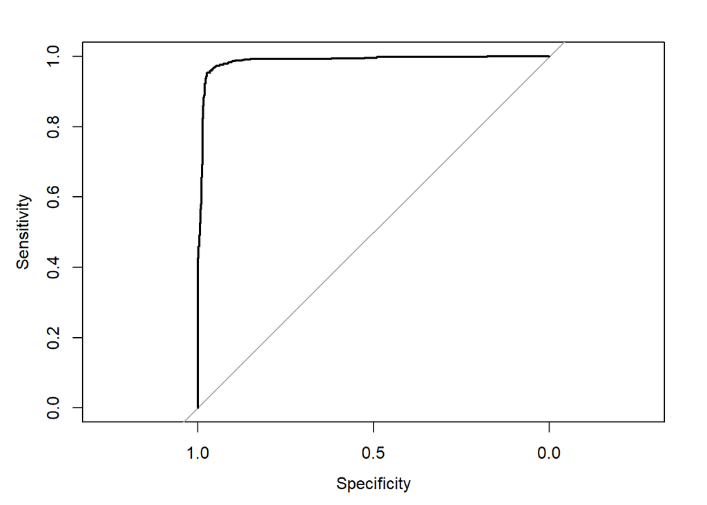

```r
#The following code will calculate the Area under the Curve
rocCurve <- roc(test$class, test_pred)
plot(rocCurve)
```

```r
auc(rocCurve)
```

```
## Area under the curve: 0.9867
```

```r
#The plot and diagnostics demonstrate the high predictive accuracy of our model
```

## Testing

In UCI’s Machine Learning Repository, there is a [secondary mushroom dataset](https://archive.ics.uci.edu/dataset/848/secondary+mushroom+dataset) with more data (but new entries). I will import this new data and test the accuracy of our logistic regression model for identifing whether or not mushrooms are poisonous or edible.

### Secondary Mushroom Data Preprocessing

Before we can use our test data, we must prepare it so that it is in the same format of the data used to train our linear model. Since not all columns included in our original model is in the secondary data set, we either have to create columns and estimate the data or train a new model without those columns. We chose to train a new model that will be used to evaluate the new dataset.

```r
secondary_dat=read.csv(url("https://raw.githubusercontent.com/Mattr5541/DATA_607_Project-4/main/mushroom/secondary_data.csv"))

names(secondary_dat)
```

```
## [1] "class.cap.diameter.cap.shape.cap.surface.cap.color.does.bruise.or.bleed.gill.attachment.gill.spacing.gill.color.stem.height.stem.width.stem.root.stem.surface.stem.color.veil.type.veil.color.has.ring.ring.type.spore.print.color.habitat.season"
```

```r
col_names_sec = c('class','cap_diameter', 'cap_shape', 'cap_surface', 'cap_color', 'bruises',  'gill_attachment', 'gill_spacing', 'gill_color', 'stem_height', 'stem_width', 'stem_root', 'stem_surface', 'stem_color', 'veil_type', 'veil_color', 'has_ring', 'ring_type', 'spore_print_color', 'habitat', 'season')

split_data = str_split_fixed(secondary_dat$class.cap.diameter.cap.shape.cap.surface.cap.color.does.bruise.or.bleed.gill.attachment.gill.spacing.gill.color.stem.height.stem.width.stem.root.stem.surface.stem.color.veil.type.veil.color.has.ring.ring.type.spore.print.color.habitat.season, pattern = ";", n = 21)

test_2_df=as.data.frame(split_data)

names(test_2_df)=col_names_sec



test_2_df$class = as.numeric(factor(test_2_df$class, levels=c('p','e')))

test_2_df$cap_shape = as.numeric(factor(test_2_df$cap_shape, levels=c('b', 'c', 'x', 'f', 'k', 's')))



test_2_df$cap_color = as.numeric(factor(test_2_df$cap_color, levels=c("n","o","w","y","b","g","p","e","r","u","c","k","l")))


test_2_df$bruises = as.numeric(factor(test_2_df$bruises, levels=c('t', 'f')))

test_2_df$gill_attachment = as.numeric(factor(test_2_df$gill_attachment, levels=c('a','d','e', 'f')))


test_2_df$gill_color = as.numeric(factor(test_2_df$gill_color, levels=c("n","o","w","y","b","g","p","e","r","u","c","k","l")))


test_2_df$veil_type = as.numeric(factor(test_2_df$veil_type, levels=c('p', 'u')))


test_2_df$veil_color = as.numeric(factor(test_2_df$veil_color, levels=c("n","o","w","y","b","g","p","e","r","u","c","k","l")))


test_2_df$habitat = as.numeric(factor(test_2_df$habitat, levels=c('g', 'l', 'm', 'p', 'u', 'w', 'd')))








test_2 = test_2_df %>%
  select(c(class,`cap_shape`,`cap_color`,bruises,`gill_attachment`, `gill_color`, `veil_type`,`veil_color`, `habitat`))

train_model_2 = glm(class ~ cap_shape  + cap_color + bruises +  gill_attachment + gill_color +veil_type+ veil_color  +
                habitat, data = train, family = binomial)


summary(train_model_2)
```

```
##
## Call:
## glm(formula = class ~ cap_shape + cap_color + bruises + gill_attachment +
##     gill_color + veil_type + veil_color + habitat, family = binomial,
##     data = train)
##
## Coefficients: (1 not defined because of singularities)
##                   Estimate Std. Error z value Pr(>|z|)
## (Intercept)      2.454e+01  1.144e+03   0.021   0.9829
## cap_shape        2.748e-02  5.095e-02   0.539   0.5896
## cap_color       -8.603e-02  1.686e-02  -5.102 3.37e-07 ***
## bruises         -1.699e+00  8.255e-02 -20.577  < 2e-16 ***
## gill_attachment  7.090e+00  1.258e+02   0.056   0.9551
## gill_color      -7.867e-02  9.467e-03  -8.309  < 2e-16 ***
## veil_type               NA         NA      NA       NA
## veil_color      -1.452e+01  3.601e+02  -0.040   0.9678
## habitat         -2.901e-02  1.561e-02  -1.859   0.0631 .
## ---
## Signif. codes:  0 '***' 0.001 '**' 0.01 '*' 0.05 '.' 0.1 ' ' 1
##
## (Dispersion parameter for binomial family taken to be 1)
##
##     Null deviance: 5260.6  on 3950  degrees of freedom
## Residual deviance: 4433.2  on 3943  degrees of freedom
## AIC: 4449.2
##
## Number of Fisher Scoring iterations: 13
```

```r
#generate predictions
train_pred_2 = predict(train_model_2, type = "response", newdata = train)
train_pred_class_2 = ifelse(train_pred_2 > 0.5, 1, 0)

#assess the acuracy of those predictions
confusionMatrix(factor(train_pred_class_2), factor(train$class))
```

```
## Confusion Matrix and Statistics
##
##           Reference
## Prediction    0    1
##          0 1049  464
##          1  466 1972
##
##                Accuracy : 0.7646
##                  95% CI : (0.7511, 0.7778)
##     No Information Rate : 0.6166
##     P-Value [Acc > NIR] : <2e-16
##
##                   Kappa : 0.5021
##
##  Mcnemar's Test P-Value : 0.9738
##
##             Sensitivity : 0.6924
##             Specificity : 0.8095
##          Pos Pred Value : 0.6933
##          Neg Pred Value : 0.8089
##              Prevalence : 0.3834
##          Detection Rate : 0.2655
##    Detection Prevalence : 0.3829
##       Balanced Accuracy : 0.7510
##
##        'Positive' Class : 0
##
```

```r
cv_results_2 = train(class ~ cap_shape + cap_color + bruises + odor + gill_attachment + gill_color + veil_color + habitat, data = train, method = "glm",
               trControl = trainControl(method = "cv", number = 10), family = 'binomial')
print(cv_results_2)
```

```
## Generalized Linear Model
##
## 3951 samples
##    8 predictor
##
## No pre-processing
## Resampling: Cross-Validated (10 fold)
## Summary of sample sizes: 3556, 3556, 3556, 3556, 3556, 3556, ...
## Resampling results:
##
##   RMSE       Rsquared   MAE
##   0.4179356  0.2624879  0.3584861
```

The second model trained was a less accurate than the first one. But this was expected since the secondary dataset did not the complete set of columns as our original dataset. Lets evaluate this second model on our secondary test data.

```r
test_pred_2 = predict(train_model_2, type = "response", newdata = test_2)
test_pred_class_2 = ifelse(test_pred_2 > 0.5, 2, 1)

test_pred_class_2 = factor(test_pred_class_2, levels = c(1, 2))
test_2$class = factor(test_2$class, levels = c(1, 2))


confusionMatrix(test_pred_class_2, test_2$class)
```

```
## Confusion Matrix and Statistics
##
##           Reference
## Prediction    1    2
##          1 2400  945
##          2   95    0
##
##                Accuracy : 0.6977
##                  95% CI : (0.682, 0.713)
##     No Information Rate : 0.7253
##     P-Value [Acc > NIR] : 0.9998
##
##                   Kappa : -0.0528
##
##  Mcnemar's Test P-Value : <2e-16
##
##             Sensitivity : 0.9619
##             Specificity : 0.0000
##          Pos Pred Value : 0.7175
##          Neg Pred Value : 0.0000
##              Prevalence : 0.7253
##          Detection Rate : 0.6977
##    Detection Prevalence : 0.9724
##       Balanced Accuracy : 0.4810
##
##        'Positive' Class : 1
##
```

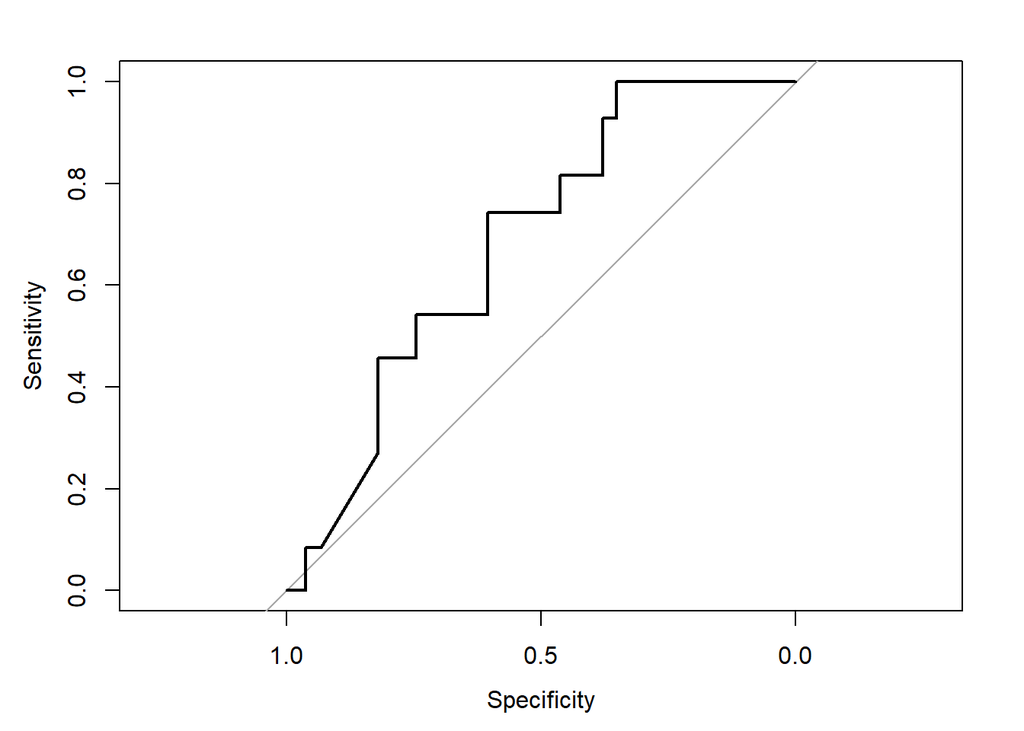

```r
rocCurve_2 = roc(test_2$class, test_pred_2)
plot(rocCurve_2)
```

```r
auc(rocCurve_2)
```

```
## Area under the curve: 0.6834
```

1. **True Positives (2400)**: The model correctly predicted 2400 instances as ‘poisonous’ mushrooms.
2. **True Negatives (0)**: The model did not correctly predict any instances of ‘edible’ mushrooms.
3. **False Positives (945)**: The model incorrectly classified 945 instances as ‘poisonous’ , which were actually ‘edible’.
4. **False Negatives (95)**: The model incorrectly classified 95 instances as ‘edible’, which were actually ‘poisonous’.

### Model Performance Metrics

- **Accuracy (69.77%)**: The model correctly predicted about 70% of the instances. However, this is below the No Information Rate, suggesting that the model might not be performing better than random guessing for this dataset.
- **Kappa (-0.0528)**: This means that the model is not suitable for this dataset.
- **Sensitivity (96.19%)**: The model is highly sensitive in predicting poisonous mushrooms but fails significantly in predicting edible mushrooms, as indicated by a specificity of 0%.
- **Specificity (0%)**: The model fails to correctly identify any true negatives (edible mushrooms)
- **Positive Predictive Value (71.75%)**: When the model predicts poisonous mushrooms, it is correct about 72% of the time.

Our secondary model was not as accurate for predicting whether the secondary dataset is poisonous or not. In the future, I would consider using more columns and adding the missing values to my new dataset (either by inserting the mean, or individually mushroom by mushroom getting that data point). The more data a model has to train on, the better the model will get ideally.

## Conclusion

In this project, we implemented and evaluated a logistic regression model to classify mushrooms as edible or poisonous,

The logistic regression model, trained on the training set, demonstrated effective learning of the relationships between various mushroom features and their edibility status. The model’s performance was initially evaluated on the training data using a confusion matrix and cross-validation, showing promising results.

Our logistic regression model had good results, with high accuracy, sensitivity, and specificity. These outcomes suggest that the model effectively distinguishes between edible and poisonous mushrooms, aligning well with known characteristics of these fungi. Notably, features like odor, gill color, and cap shape have emerged as significant predictors.

There are some results that we should explore in the future. For instance, the model’s occasional confusion between certain classes of mushrooms, as evidenced by false positives and negatives, hint at smaller morphological or chemical similarities that aren’t captured by the dataset. In the future, we could explore more complex models, like neural networks, to capture complex patterns. Integrating datasets from different geographic and environmental data could enhance the model’s applicability to diverse real-world scenarios.